# Chapter 18: Inference for Two-Way Tables

# Overview

- 18.1 Randomization test of independence
  - 18.1.1 Expected counts in two-way tables
  - 18.1.2 The observed chi-squared statistic
  - 18.1.3 Variability of the statistic
  - 18.1.4 Observed statistic vs. null chi-squared statistics
- 18.2 Mathematical model for test of independence
  - 18.2.1 The chi-squared test of independence
  - 18.2.2 Variability of the chi-squared statistic
  - 18.2.3 Observed statistic vs. null chi-squared statistics

# 18.1 Randomization test of independence

Can the type of question influence how much a seller reveals about defects?

- Explanatory: Question asked
  - General: What can you tell me about it?
  - Positive Assumption: It does not have any problems, does it?
  - Negative Assumption: What problems does it have?
- Response: Does the seller disclose the problem?

## Two-way table

| Question | Disclose problem | Hide problem | Total |
| --- | --- | --- | --- |
| General | 2 | 71 | 73 |
| Positive assumption | 23 | 50 | 73 |
| Negative assumption | 36 | 37 | 73 |
| Total | 61 | 158 | 219 |

## 18.1.1 Expected counts in two-way tables

- If the type of question didn’t matter (null hypothesis), then we would expect the same number of disclosures, *independent* of the question asked.
- Overall, the seller disclosed the problem 61 out of 219 times, so we would *expect* $\frac{61}{219} \times 73 \approx 20.33$ disclosures for 73 sellers.

| Question | Disclose problem | Hide problem | Total |
| --- | --- | --- | --- |
| General | 2 *(20.33)* | 71 *(52.67)* | 73 |
| Positive assumption | 23 *(20.33)* | 50 *(52.67)* | 73 |
| Negative assumption | 36 *(20.33)* | 37 *(52.67)* | 73 |
| Total | 61 | 158 | 219 |

## 18.1.3 Variability of the statistic

We can simulate $X^2$ statistics under the assumption $H_0$ that the question has no effect:

- 219 Cards
- 61 green (disclose), 158 blue (hide)
- Shuffle and deal into *three* piles, 73 each.
- Make a 2-way table.
- Compute the *simulated null statistic* $X^2$.

## Simulated Two-way table

Simulated and *(expected)* counts:

| Question | Disclose problem | Hide problem | Total |
| --- | --- | --- | --- |
| General | 29 *(20.33)* | 44 *(52.67)* | 73 |
| Positive assumption | 15 *(20.33)* | 58 *(52.67)* | 73 |
| Negative assumption | 17 *(20.33)* | 56 *(52.67)* | 73 |
| Total | 61 | 158 | 219 |

## Simulated null chi-squared statistic

$${\scriptsize
\begin{aligned}
&\text{General formula} &&
\frac{(\text{observed count } - \text{expected count})^2}
{\text{expected count}} \\
&\text{Row 1, Col 1} &&
\frac{(29 - 20.33)^2}{20.33} = 3.7 \\
&\text{Row 2, Col 1} &&
\frac{(15 - 20.33)^2}{20.33} = 1.4 \\
& \hspace{9mm}\vdots &&
\hspace{13mm}\vdots \\
&\text{Row 3, Col 2} &&
\frac{(56 - 52.67)^2}{52.67} = 0.211
\end{aligned}
} \\
X^2 = 3.7 + 1.4 + \dots + 0.211 = 8$$

## 18.1.4 Observed statistic vs. null chi-squared statistics

- We simulate 1000s of $X^2$ statistics this way to create a *null distribution*.
- Then we count how many are *as or more extreme* as our observed chi-square statistic ($X^2 = 40.13$).
  - This is the P-value.
- The distribution only has a right-hand tail, because $X^2$ is always positive.

## Interpretation

- The P-value is 0.000.
- We have very strong evidence that the type of question asked is associated with whether or not the seller reveals defects.
- The two variables are *not independent*.

# Group Activity: Organ Donation

## Organ Donor Consent

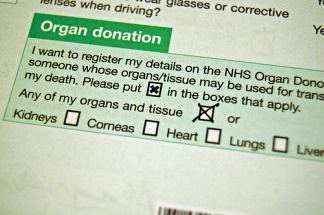

[figure not shown]

## Experiment

Researchers asked *volunteer* subjects to imagine they moved to a new state, applied for a driver’s license, and needed to decide whether or not to become an organ donor. Researchers created *three different versions* of the survey, each with a different donor recruiting strategy. Subjects were *randomly assigned* to one of the three types of recruiting strategies.

1. The default option is to be an organ donor, and individuals have to opt out of organ donation (opt-*out* group).
2. The default option is to not be an organ donor, and individuals have to opt in to organ donation (opt-*in* group).
3. There is no default option, and individuals have to choose whether or not they will be an organ donor (*neutral* group).

## Hypotheses

- **Null Hypothesis.** The recruiting strategy is independent of the decision to donate.
- **Alternative Hypothesis.** The recruiting strategy is associated with whether or not the person decides to donate.

## Organ Donor Data

Researchers found that 23 of 55 subjects in the opt-in group chose to be organ donors, 41 of 50 in the opt-out group chose to be organ donors, and 44 of 56 in the neutral group chose to be organ donors.

## Group Exercises

1. Open the [Multiple Proportions applet](http://www.rossmanchance.com/applets/ChiSqShuffle.html?hideExtras=1) with the preloaded organ donor data. Click the *Show Table* checkbox to see the two-way table. Select $\chi^2$ from the *Statistic* drop down menu. **Record** the observed chi-squared statistic.
2. Based on the bar blot (or the table), does it appear that the recruiting strategy is associated with the decision to donate? Be ready to give a reason for your answer.
3. Simulate a null distribution of chi-squared statistics. **Record** a *p-value.* Based on this p-value, **record** a sentence summarizing your conclusion in the context of this study.
4. Check the box for *Overlay Chi-squared distribution*. What do you notice?

# 18.2 Mathematical model for test of independence

## 18.2.1 The chi-squared test of independence

- The *Chi-squared distribution* is a mathematical model that predicts the sampling distribution of the chi-squared statistic.
- You need to specify the *degrees of freedom*, which controls how fat the tail is.
  - The degrees of freedom depends on the number of levels in your categorical variables.

## 18.2.2 Variability of the chi-squared statistic

- Conditions:
  - The observations should be *independent*.
  - The *expected counts for each cell of the table should be at least 5.*

If the conditions are met, then the sampling distribution will be approximately Chi-squared with $(R-1)\times(C-1)$ degrees of freedom, where $R$ and $C$ are the number of rows and columns in the two-way table.

## 18.2.3 Observed statistic vs. null chi-squared statistics

In the Question/Seller example, we had $X^2 = 40.13$ with 2 degrees of freedom.

```r
pchisq(40.13, df = 2, lower.tail = FALSE)
```

```
[1] 1.93144e-09
```

Or equivalently,

```r
1- pchisq(40.13, df = 2)
```

```
[1] 1.93144e-09
```

## Chi-squared test in R

```r
sellerTable <- as.table(rbind(c(2, 71), c(23, 50), c(36,37)))
chisq.test(sellerTable)
```

```
    Pearson's Chi-squared test

data:  sellerTable
X-squared = 40.128, df = 2, p-value = 1.933e-09
```